# Multilevel modeling (mlm) with brms

2019-06-13

# 1 Setup

```r
library(tidyverse)
library(sjmisc)
library(here)
library(brms)
library(sjstats)
library(ggformula)
library(broom)
```

Where am I?

```r
here::here()
```

```
## [1] "/Users/sebastiansaueruser/Documents/research/Achtsamkeit_Studien/Necker/necker-cube-replication-saueretal2012"
```

## 1.1 Load data

```r
d <- readRDS(file = paste0(here::here(), "/objects/data-modeling-rt-level.Rdata"))
```

# 2 Specify models

This section should be parallel to the lme4 models, but I’ll fit the models via stan using the R package `brms`. I’ll index all the models fit using `brms` with a suffixed “b”.

## 2.1 `m04b`

This is the statistiscal specification of the model:

Likelihood:

- $\text{rt} \sim \text{Normal}(\mu, \sigma)$ - That’s type of likelihood, ie the conditional values of the predicted variable are normall distributed
- $\mu_i = \alpha + \beta_1 \text{ms}_i + \beta_2\text{mt}$ - That’s the (deterministic) regression function

*ms* refers to *mindfulness score*, *mt* to *mindfulness trainint*, and *rt* is the reaction time (it’s not specified whether it’s the corrected/sanitized or the raw one, being lazy at this point). $\alpha$ is the Intercept, and $\sigma$ the residual distribution variability.

### 2.1.1 Define priors

Here’s an overview on possible prior.

```r
get_prior(rt2_effect ~ factor(mindfulness_training) + mindfulness_score_z + (1|id) + (1|type),
            data = d)
```

```
##                      prior     class                        coef group
## 1                                  b
## 2                                  b factormindfulness_training1
## 3                                  b         mindfulness_score_z
## 4  student_t(3, -324, 408) Intercept
## 5     student_t(3, 0, 408)        sd
## 6                                 sd                                id
## 7                                 sd                   Intercept    id
## 8                                 sd                              type
## 9                                 sd                   Intercept  type
## 10    student_t(3, 0, 408)     sigma
##    resp dpar nlpar bound
## 1
## 2
## 3
## 4
## 5
## 6
## 7
## 8
## 9
## 10
```

Now here we define them:

```r
priors_m04b <- c(prior(normal(0,2000), class = b),  # Predictor
                 prior(normal(0,2000), class = Intercept),
                 prior(cauchy(0, 2000), class = sigma))
```

A Half Cauchy is chosen for the residual distribution, $\sigma$. That’s a typical choice. Note that the Cauchy distribution has very fat tails, and no expected value.

It has two parameters, a scale ($\x_0$) and a spread parameter ($\lambda$), with the obvious intuitive meaning.

I’m following here the advice by Richard McElreath.

```r
m04b <- brm(rt2_effect ~ factor(mindfulness_training) + mindfulness_score_z + (1|id) + (1|type),
            data = d,
            prior = priors_m04b,
            iter = 3000, warmup = 1500, chains = 2, cores = 4,
            seed = 123,
            file = "m04b")

print(m04)
```

```
## Error in print(m04): object 'm04' not found
```

Took about 40 Min. to run on my machine.

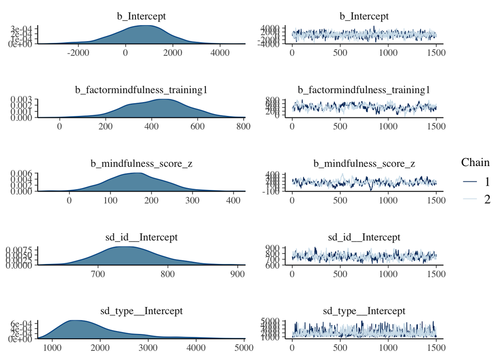

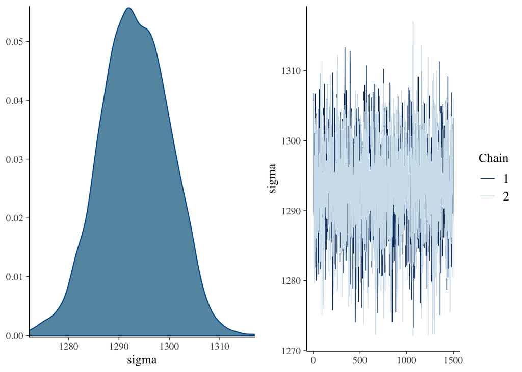

```r
plot(m04b)
```

## 2.2 m05b

### 2.2.1 Fix model specification

The above specification was not explicit (or even wrong) about the multilevel priors. Let’s fix that.

1. Overall model:
- Likelihood: $\text{rt}_i \sim \text{Normal}(\mu_i, \sigma)$
- Linear model: $\mu_i = \alpha + \alpha_{id[i]} + \alpha_{type[i]} + \beta_1 \text{ms}_i + \beta_2 \text{mt}_i$
2. Intercepts/alphas:
- Overall intercept: $\alpha \sim \text{Normal}(0, 2000)$
- Prior for person distribution (L2): $\alpha_{id} \sim \text{Normal}(\alpha_{id}, \sigma_{id})$
- Prior for type (block) distribution (L2): $\alpha_{type} \sim \text{Normal}(\alpha_{type}, \sigma_{type})$
3. Priors for the variability (of the residuals): All the same
- Overall residual variability: $\sigma \sim \text{HalfCauchy}(0, 2000)$
- Person variability: $\sigma_{id} \sim \text{HalfCauchy}(0, 2000)$
- Type (block) variability: $\sigma_{type} \sim \text{HalfCauchy}(0, 2000)$
4. Priors for the betas: All the same
- mindfulness score beta: $beta_{ms} \sim \text{Normal}(0, 2000)$
- mindfulness training beta: $beta_{ms} \sim \text{Normal}(0, 2000)$

Mind you that `type` is a within factor with the levels `hold` and `flip`. The index $i$ refers to Level 1, ie one trial (not person!). Note that the predictors are z-normalized.